# ADS Project1: Explore the relationship between focus on immigration topic during inauguration speeches and immigration statistics

Kexin Nie

Feb 3rd, 2017

# Introduction

As we all have known, just few days after the inauguration ceremony of Donald Trump, the new executive orders for immigrants and refugees came out. Those policies has had a significant effect on everyone in this country. Many have been distressed and refused to accept the order. Trump’s negative attitude towards immigrants and refugees could be seen from some of his speeches last year, and he did come up with new orders against them. According to Trump’s new order, we might think whether the inauguration speeches reflect the trend of immigration policies, which might affect the immigration statistics. In this project, data mining techniques will be used to explore the relationship between inauguration speeches and immigration statistics.

# Method

To estimate the importance of immigration topic in a speech, we decide to use word frequency. If in a specific speech, the president mentions many immigration related words, it might imply that the president focus more on immigration topic than other presidents. We first need to find which words are related to immigration topic, then we count word frequency of those selected words in each speech.

step 0-Install and load libraries

step1-Import speeches

step2-Find immigration related words using term correlations

```
## $immigration
##       monroe   protective       courts expenditures     taxation
##         0.69         0.69         0.67         0.67         0.67
##      methods
##         0.66
```

```
## $immigrants
##  invented     vowed    bridge engineers      harm
##      0.81      0.81      0.77      0.69      0.69
```

As we can see from the results, we choose the top 12 words with highest correlation to “immigration” and “immigrants”(including themselves).We drop the first word “monroe” since it only appears in certain speech, it might be certain policy conducted by certain president, so we can ignore it.

step3- Compare the frequency of immigration related words in speeches

To calculate the immigration-related words frequency, we count word frequency for the selected words above, then we obtain a sum for each speech weighted by the correlation of each word. This method makes sense since words less similar to “immigrants” or “immigration” should be given less weights.

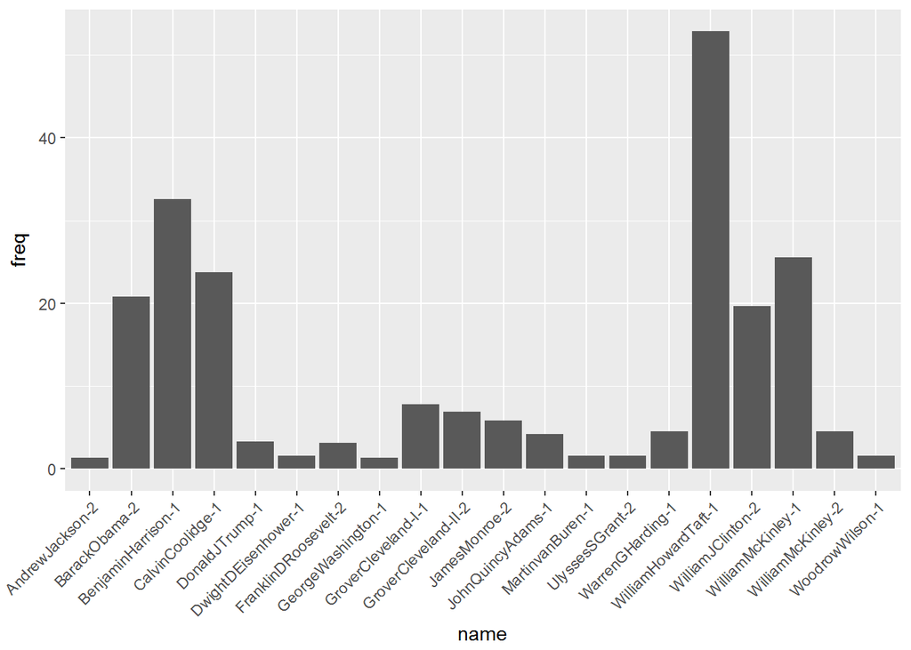

step4-Analyze attitude of the speech through sentiment analysis

After understanding how much each president talked about immigration issues in their speeches, we want to look into their attitudes towards immigration topic. First we only choose the sentences in each speech that contain the “key word” for immigration topic. Then we do a sentiment analysis for each speech only on immigration-related parts. A higher sentiment score represents a more positive attitude towards immigration. Please notice that we drop some speeches during sentiment analysis. Because when we include the sentences containing “key word”, some speeches might not have any sentence matching. To make the calculation tidy, we drop these rows with NA values.

step5-Compare the previous results to immigration statistics

For immigration data, we use the number of foreign nationals who are granted lawful permanent residence (i.e., immigrants who receive a “green card”), admitted as temporary nonimmigrants, granted asylum or refugee status, or are naturalized from 1820 to 2015 table from https://www.dhs.gov/immigration-statistics/yearbook/2015/table1 This table reflects the amount of new immigrants every year. The trend of the data might be affected by some factors such as economy or “global trend” through time, so using the changing rate might be more reasonable than the data itself. Change rates do a better job in representing the change of immigration statistic after the speech. We define

# Change rate[i]=(nt[i]-n0[i])/n0[i]

i- ith speech (belongs to president X,term Y)

n0[i]-Year X started to work in term Y

nt[i]-Year X ended to work in term Y

Then we plot changerates, word frequency and sentiment scores on same plot. Since there exists many other complicate factors who affect changerates, running a regression model might not be efficient for right now, so we will look at the result plot and find some patterns.

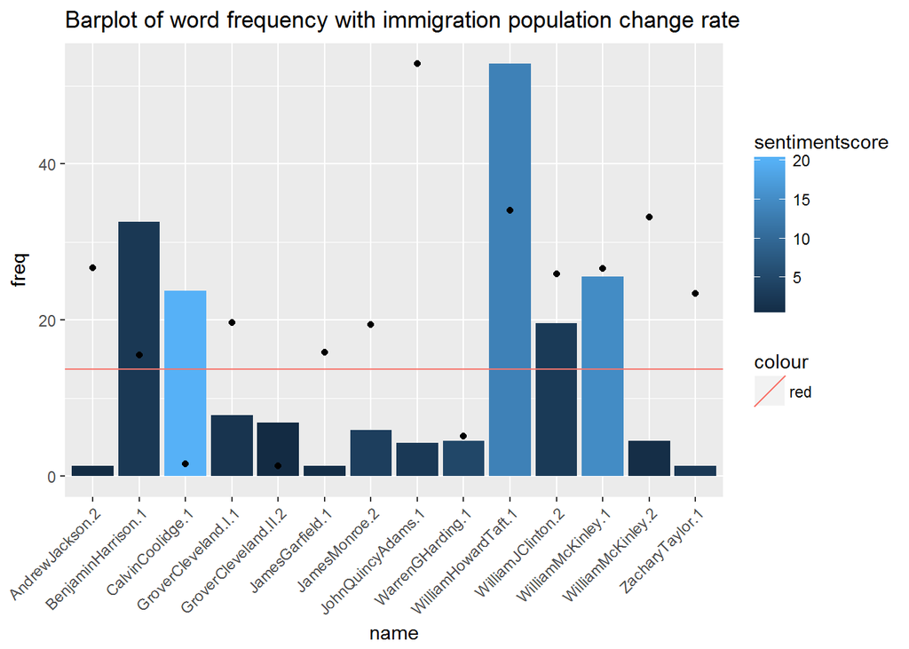

In the result plot, word frequency is showed in barplot with colors representing sentiment scores. The bars with a lighter color mean more positive attitude towards immigration topic. Also the points represent the change rate of immigration statistics after the speech. Since we rescale the changerates just for plotting reasons, the points below the red line show negative changerate, which means a decrease in immigration statistics.

# Summary

After finding word frequency and sentiment scores for immigration topic, we compare them to the change rate of yearly new immigrants numbers. After exploring the result plot, we notice for sometime, immigration statistics might have a positive relationship with sentiment scores and immigration word frequency. It might because a positive attitude and a lot focus on immigration during inauguration speech might reflect the president’s attitude towards immigration problem, which might affect his policies. But this claim is not always true since we observe some points in the plot against it. It might due to 1) There are many other factors which affect the immigration statistics other than immigration policies, such as economy and wars. 2) The random errors which happen in data mining process. Sentences that contain “immigration-related words” might not be immigration-related.

# Further Discussion

To figure out more about the relationship between inauguration speech and immigration, readers are suggested to read through some of the speeches to get a better sense of the president’s attitude. If we want to predict the future immigration statistics change ratio, we could build a regression model. But to make the model valid, we need to find some other factors that might also explain immigration statistics, such as GDP.